# Тестовое Тинькофф

Выполнил Чайников Константин

Тестовое задание по NLP

- * Опционально, будет плюсом

1) Сделать классификатор интентов

- Для обучения использовать датасет https://github.com/PolyAI-LDN/task-specific-datasets/banking_data/
- Сделать небольшой отчет в свободной форме для оценки качества решения (tf-idf baseline на тесте выбивает от 0.9 f1-score если не получится улучшить - не критично, но выше бейзлайна будет большим плюсом)
- Цель: написать более менее адекватную архитектуру, построить читаемый отчет
- * Реализовать Self-adjusting Dice Loss из https://www.aclweb.org/anthology/2020.acl-main.45.pdf Сравнить с Cross Entropy
- * Реализовать механизм семплинга батчей, чтобы компенсировать несбалансированность классов в датасете Сравнить с обычным семплингом

2) Обернуть классификатор в REST сервис

- Метод POST /classify
- На вход подается текст примера
- В ответ возвращается строковый тег интента
- Сервис должен быть завернут в docker контейнер

```python
from google.colab import drive
drive.mount('/content/drive')
```

```python
!git clone https://github.com/PolyAI-LDN/task-specific-datasets
# ссылка на тестовоые данные с лейблами
# https://github.com/congyingxia/IncrementalFSTC/blob/88b17da85024e015372bb5171b271dfcfe6b6a1d/data/banking77/split/total_test.txt
!unzip /content/drive/MyDrive/data_for_tinkoff/total_test.txt.zip
```

```
Cloning into 'task-specific-datasets'...
remote: Enumerating objects: 103, done.
remote: Counting objects: 100% (103/103), done.
remote: Compressing objects: 100% (58/58), done.
remote: Total 103 (delta 58), reused 77 (delta 45), pack-reused 0
Receiving objects: 100% (103/103), 1001.92 KiB | 3.06 MiB/s, done.
Resolving deltas: 100% (58/58), done.
Archive:  /content/drive/MyDrive/data_for_tinkoff/total_test.txt.zip
 extracting: total_test.txt
```

```python
!pip install transformers
!pip install sentencepiece
```

```
     |████████████████████████████████| 2.5MB 10.0MB/s
     |████████████████████████████████| 901kB 34.4MB/s
     |████████████████████████████████| 3.3MB 35.7MB/s
     |████████████████████████████████| 1.2MB 14.7MB/s
```

# Обязательно! Перезапускаем ядро

среда выполнения -> перезапустить среду выполнения

```python
!apt-get install swig
!pip install jamspell
!tar -xvzf /content/drive/MyDrive/data_for_tinkoff/en.tar.gz
```

[output not shown]

```python
import jamspell
corrector = jamspell.TSpellCorrector() # корректор опечаток
corrector.LoadLangModel('en.bin') # предобученную модель взял здесь
#                                   https://github.com/bakwc/JamSpell
```

```
True
```

# Часть 1 Анализ данных

Импортируем библиотеки и проверяем их версии.

```python
print('Версии используемых библиотек')
import numpy as np
print('numpy', np.__version__)
import pandas as pd
print('pandas', pd.__version__)

import seaborn as sns
print('seaborn', sns.__version__)

import matplotlib.pyplot as plt
import matplotlib
plt.style.use('ggplot')
print('matplotlib', matplotlib.__version__)

import random

import torch
from transformers import BertTokenizer, BertConfig
from transformers import AdamW, BertForSequenceClassification
import torch.nn.functional as F
import torch.nn as nn
import torch.optim as optim
print('torch', torch.__version__)

from sklearn.metrics import f1_score
import sklearn
print('sklearn', sklearn.__version__)

import transformers
print('transformers', transformers.__version__)

import jamspell
#print('jamspell', jamspell.__version__)

#import sentencepiece
#print('sentencepiece', sentencepiece.__version__)

#import swig
#print('swig', swig.__version__)

#import collections
#print('collections', collections.__version__)

import re
print('re', re.__version__)

import nltk
print('nltk', nltk.__version__)

import IPython
print('IPython', IPython.__version__)
from IPython.display import clear_output
from collections import Counter
import re

import tqdm

print('tqdm', tqdm.__version__)
#from tqdm.notebook import tqdm, trange
USE_CUDA = torch.cuda.is_available()
device = torch.device("cuda" if USE_CUDA else "cpu")
```

```
Версии используемых библиотек
numpy 1.19.5
pandas 1.1.5
seaborn 0.11.1
matplotlib 3.2.2
torch 1.9.0+cu102
sklearn 0.22.2.post1
transformers 4.7.0
re 2.2.1
nltk 3.2.5
IPython 5.5.0
tqdm 4.41.1
```

Будем сидировать важные моменты

```python
def set_seed():
    random.seed(42)
    np.random.seed(42)
    torch.random.manual_seed(42)
    torch.cuda.random.manual_seed(42)
    torch.cuda.random.manual_seed_all(42)
```

```python
df_train = pd.read_csv('/content/task-specific-datasets/banking_data/train.csv')
df_test = pd.read_csv('/content/total_test.txt', sep='\t', names= ['category', 'text'])
```

```python
df_train.sample(3)
```

|  | text | category |
| --- | --- | --- |
| 4752 | how do i get a refund for a direct debit payme... | direct_debit_payment_not_recognised |
| 334 | How are exchange rates determined? | exchange_rate |
| 6394 | I was charged two times for the same thing. | transaction_charged_twice |

```python
df_test.sample(3)
```

|  | category | text |
| --- | --- | --- |
| 2844 | activate_my_card | How can I activate my card so I can start usin... |
| 665 | pending_top_up | Hi I'm a new customer and tried topping up for... |
| 2247 | receiving_money | I get paid in GBP. Should I configure this and... |

```python
df_train.info()
```

```
<class 'pandas.core.frame.DataFrame'>
RangeIndex: 10003 entries, 0 to 10002
Data columns (total 2 columns):
 #   Column    Non-Null Count  Dtype
---  ------    --------------  -----
 0   text      10003 non-null  object
 1   category  10003 non-null  object
dtypes: object(2)
memory usage: 156.4+ KB
```

```python
labels_dict = {}
weight = [] # пригодятся для лосса в будущем
i = 0
for cat, j in df_train["category"].value_counts().items():
    labels_dict[cat] = i
    weight.append(187/j)
    i+=1
label_to_text = {j:i for i,j in labels_dict.items()}

def f(text):
    return labels_dict[text]

X_train = df_train.text
X_test  = df_test.text
y_train = df_train.category.apply(f)
y_test = df_test.category.apply(f)
```

```python
label_to_text
```

```
{0: 'card_payment_fee_charged',
 1: 'direct_debit_payment_not_recognised',
 2: 'balance_not_updated_after_cheque_or_cash_deposit',
 3: 'wrong_amount_of_cash_received',
 4: 'cash_withdrawal_charge',
 5: 'transaction_charged_twice',
 6: 'declined_cash_withdrawal',
 7: 'transfer_fee_charged',
 8: 'transfer_not_received_by_recipient',
 9: 'balance_not_updated_after_bank_transfer',
 10: 'request_refund',
 11: 'card_payment_not_recognised',
 12: 'card_payment_wrong_exchange_rate',
 13: 'extra_charge_on_statement',
 14: 'wrong_exchange_rate_for_cash_withdrawal',
```

[output cut: 62 more lines]

```python
import json

# Serialize data into file:
json.dump( label_to_text, open( "label_to_text.json", 'w' ) )

# Read data from file:
label_to_text_1 = json.load( open( "label_to_text.json" ) )
```

```python
label_to_text_1
```

```
{'0': 'card_payment_fee_charged',
 '1': 'direct_debit_payment_not_recognised',
 '10': 'request_refund',
 '11': 'card_payment_not_recognised',
 '12': 'card_payment_wrong_exchange_rate',
 '13': 'extra_charge_on_statement',
 '14': 'wrong_exchange_rate_for_cash_withdrawal',
 '15': 'Refund_not_showing_up',
 '16': 'reverted_card_payment?',
 '17': 'cash_withdrawal_not_recognised',
 '18': 'activate_my_card',
 '19': 'pending_card_payment',
 '2': 'balance_not_updated_after_cheque_or_cash_deposit',
 '20': 'cancel_transfer',
 '21': 'beneficiary_not_allowed',
 '22': 'card_arrival',
 '23': 'declined_card_payment',
 '24': 'pending_top_up',
 '25': 'pending_transfer',
 '26': 'top_up_reverted',
 '27': 'top_up_failed',
 '28': 'pending_cash_withdrawal',
 '29': 'card_linking',
 '3': 'wrong_amount_of_cash_received',
 '30': 'failed_transfer',
 '31': 'visa_or_mastercard',
 '32': 'declined_transfer',
 '33': 'card_about_to_expire',
 '34': 'country_support',
 '35': 'getting_spare_card',
 '36': 'supported_cards_and_currencies',
 '37': 'transfer_timing',
 '38': 'automatic_top_up',
 '39': 'verify_top_up',
 '4': 'cash_withdrawal_charge',
 '40': 'apple_pay_or_google_pay',
 '41': 'fiat_currency_support',
 '42': 'change_pin',
 '43': 'exchange_charge',
 '44': 'disposable_card_limits',
```

[output cut: 22 more lines]

```
 '65': 'unable_to_verify_identity',
 '66': 'getting_virtual_card',
 '67': 'top_up_limits',
 '68': 'get_disposable_virtual_card',
 '69': 'receiving_money',
 '7': 'transfer_fee_charged',
 '70': 'atm_support',
 '71': 'compromised_card',
 '72': 'lost_or_stolen_card',
 '73': 'card_swallowed',
 '74': 'card_acceptance',
 '75': 'virtual_card_not_working',
 '76': 'contactless_not_working',
 '8': 'transfer_not_received_by_recipient',
 '9': 'balance_not_updated_after_bank_transfer'}
```

```python
for i in label_to_text.keys():
    if not label_to_text_1[str(i)] == label_to_text[i]:
        print('Error!')
```

Количество классов с тестовом и тренировачном наборе

```python
df_train.category.nunique()
```

```
77
```

```python
df_test.category.nunique()
```

```
77
```

Посмотрим сколько объектов каждого класса

```python
df_train.category.value_counts()
```

```
card_payment_fee_charged                            187
direct_debit_payment_not_recognised                 182
balance_not_updated_after_cheque_or_cash_deposit    181
wrong_amount_of_cash_received                       180
cash_withdrawal_charge                              177
                                                   ...
lost_or_stolen_card                                  82
card_swallowed                                       61
card_acceptance                                      59
virtual_card_not_working                             41
contactless_not_working                              35
Name: category, Length: 77, dtype: int64
```

Явный дисбаланс классов

```python
df_test.category.value_counts()
```

```
disposable_card_limits         40
exchange_charge                40
card_payment_not_recognised    40
passcode_forgotten             40
fiat_currency_support          40
                               ..
card_delivery_estimate         40
transfer_fee_charged           40
pending_top_up                 40
why_verify_identity            40
transfer_timing                40
Name: category, Length: 77, dtype: int64
```

```python
df_train.info()
```

```
<class 'pandas.core.frame.DataFrame'>
RangeIndex: 10003 entries, 0 to 10002
Data columns (total 2 columns):
 #   Column    Non-Null Count  Dtype
---  ------    --------------  -----
 0   text      10003 non-null  object
 1   category  10003 non-null  object
dtypes: object(2)
memory usage: 156.4+ KB
```

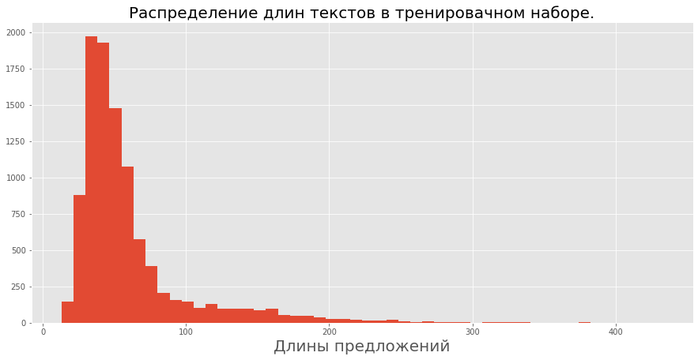

```python
plt.figure(figsize=(15,7))
plt.title('Распределение длин текстов в тренировачном наборе.', fontsize=20)
df_train.text.apply(len).hist(bins=50)
plt.xlabel('Длины предложений', fontsize=20)
plt.show()
```

```python
dlin = list(map(len, ' '.join(df_train.text.str.lower().str.replace(r'[^a-z0-9\' ]',r' ')).split()))
```

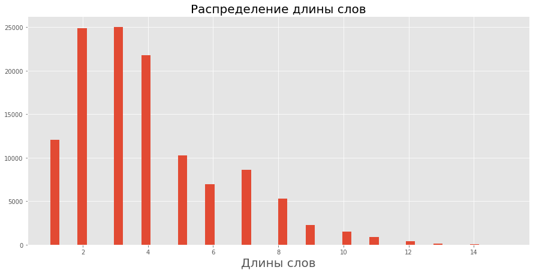

```python
plt.figure(figsize=(15,7))
plt.title('Распределение длины слов', fontsize=20)
plt.hist(dlin, bins = 50)
plt.xlabel('Длины слов', fontsize=20)
plt.show()
```

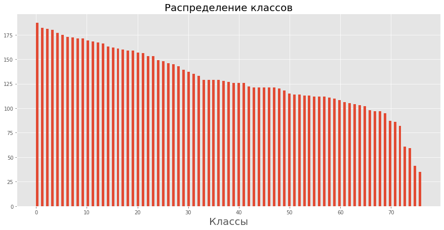

```python
plt.figure(figsize=(15,7))
plt.title('Распределение классов', fontsize=20)
y_train.hist(bins=y_train.nunique() * 2 - 1)
plt.xlabel('Классы', fontsize=20)
plt.show()
```

```python
from collections import Counter

Counter(' '.join(df_train.text.str.lower())).most_common()
```

```
[(' ', 120135),
 ('e', 53193),
 ('t', 43481),
 ('a', 41713),
 ('i', 34323),
 ('o', 33876),
 ('n', 33161),
 ('r', 25958),
 ('s', 23801),
 ('h', 23244),
 ('d', 21243),
 ('c', 19857),
 ('m', 16059),
 ('y', 14749),
 ('w', 13238),
 ('u', 13225),
 ('l', 12432),
 ('p', 11470),
 ('g', 9912),
 ('f', 8429),
 ('?', 6505),
 ('b', 4869),
 ('.', 4375),
 ('v', 4012),
 ('k', 3680),
 ("'", 2607),
 (',', 1564),
 ('x', 1345),
 ('-', 534),
 ('!', 383),
 ('j', 334),
 ('q', 322),
 ('0', 176),
 ('z', 173),
 ('1', 153),
 ('$', 87),
 ('2', 58),
 ('"', 42),
 ('£', 30),
 ('5', 28),
 ('3', 27),
 ('€', 21),
 ('8', 20),
 (';', 14),
 ('\n', 13),
 ('(', 10),
 ('/', 9),
 (')', 6),
 (':', 6),
 ('4', 4),
 ('6', 3),
 ('\xa0', 2),
 ('&', 2),
 ('|', 1),
 ('>', 1),
 ('…', 1),
 ('7', 1),
 ('%', 1)]
```

```python
Counter(' '.join(df_train.text.str.lower().str.replace(r'[^a-z0-9\' ]',r'')).split()).most_common()
```

```
[('i', 8312),
 ('my', 5684),
 ('to', 4038),
 ('a', 3565),
 ('the', 3498),
 ('card', 2672),
 ('is', 2376),
 ('it', 1849),
 ('do', 1848),
 ('can', 1842),
 ('for', 1581),
 ('how', 1520),
 ('what', 1375),
 ('why', 1365),
 ('account', 1348),
 ('you', 1216),
 ('and', 1215),
 ('money', 1130),
 ('was', 1090),
 ('transfer', 1081),
 ('me', 1037),
 ('have', 1000),
 ('that', 997),
 ('in', 983),
 ('up', 969),
 ('not', 967),
 ('on', 878),
 ('there', 876),
 ('this', 825),
 ('get', 808),
 ('payment', 745),
 ('an', 722),
 ('but', 713),
 ('need', 698),
 ('cash', 690),
 ('of', 681),
 ('from', 665),
 ('be', 645),
 ('top', 614),
 ('with', 607),
```

[output cut: 946 more lines]

```
 ('3', 4),
 ('latest', 4),
 ('following', 4),
 ('appreciate', 4),
 ('limitations', 4),
 ('euros', 4),
 ('length', 4),
 ('chose', 4),
 ('along', 4),
 ('run', 4),
 ('reaches', 4),
 ('setup', 4),
 ('ways', 4),
 ('turn', 4),
 ...]
```

# Часть 2 Baseline Классический ML (Случайный лес и логрегрессия)

```python
from sklearn.ensemble import RandomForestClassifier
from sklearn.linear_model import LogisticRegression


from sklearn.metrics import f1_score
from sklearn.feature_extraction.text import CountVectorizer
from sklearn.feature_extraction.text import TfidfVectorizer
```

```python
def train_classic(X_train, X_test, y_train, y_test):
    clf_l = LogisticRegression(random_state=42).fit(X_train, y_train)
    y_pred_l = clf_l.predict(X_test)
    f1_l = f1_score(y_test, y_pred_l, average='weighted')

    clf_r = RandomForestClassifier(random_state=42).fit(X_train.toarray(), y_train)
    y_pred_r = clf_r.predict(X_test.toarray())
    f1_r = f1_score(y_test, y_pred_r, average='weighted')

    print(f'F1 для логрегрессии    : {round(f1_l, 6)}')
    print(f'F1 для случайного леса : {round(f1_r, 6)}')
```

```python
from sklearn.feature_extraction.text import TfidfVectorizer
from sklearn.feature_extraction.text import CountVectorizer
```

```python
def count_vs_tfidf(X_train, X_test, y_train, y_test, param_tfidf= {}, param_count = {}):
    set_seed() # для повторяемости экспериментов
    vectorizer = TfidfVectorizer(param_tfidf)
    X_train_tfidf = vectorizer.fit_transform(X_train)
    X_test_tfidf = vectorizer.transform(X_test)
    print('Tfidf')
    train_classic(X_train_tfidf, X_test_tfidf, y_train, y_test)
    print('---')
    vectorizer = CountVectorizer(param_count)
    X_train_count = vectorizer.fit_transform(X_train)
    X_test_count = vectorizer.transform(X_test)
    print('Count')
    train_classic(X_train_count, X_test_count, y_train, y_test)
```

Посмотрим как работаю алгоритмы с дефолтными параметрами и с сырым текстом

```python
count_vs_tfidf(X_train, X_test, y_train, y_test, param_tfidf={'lowercase':False}, param_count={'lowercase':False})
```

```
Tfidf
F1 для логрегрессии    : 0.877251
F1 для случайного леса : 0.865825
---
Count
F1 для логрегрессии    : 0.889721
F1 для случайного леса : 0.866377
```

Возьмём нижний регистр

```python
count_vs_tfidf(X_train, X_test, y_train, y_test, param_tfidf={'lowercase':True}, param_count={'lowercase':True})
```

```
Tfidf
F1 для логрегрессии    : 0.877251
F1 для случайного леса : 0.865825
---
Count
F1 для логрегрессии    : 0.889721
F1 для случайного леса : 0.866377
```

Удалим все не буквенные символы

```python
count_vs_tfidf(X_train.str.replace(r'[^a-z0-9\' ]',r' '),
               X_test.str.replace(r'[^a-z0-9\' ]',r' '),
               y_train, y_test, param_tfidf={'lowercase':True}, param_count={'lowercase':True})
```

```
Tfidf
F1 для логрегрессии    : 0.843179
F1 для случайного леса : 0.832573
---
Count
F1 для логрегрессии    : 0.86314
F1 для случайного леса : 0.832788
```

Удалим стопслова

```python
count_vs_tfidf(X_train, X_test,
               y_train, y_test,
               param_tfidf={'lowercase':True, 'stop_words':'English'},
               param_count={'lowercase':True, 'stop_words':'English'})
```

```
Tfidf
F1 для логрегрессии    : 0.877251
F1 для случайного леса : 0.865825
---
Count
F1 для логрегрессии    : 0.889721
F1 для случайного леса : 0.866377
```

Попробуем убрать редковстречающиеся символы и заменить все конструкции по типу you're -> you are

Заменим также знаки € и £ на $ и на всякий случай ещё обработаем корректировщиком ошибок

```python
import jamspell
corrector = jamspell.TSpellCorrector() # корректор опечаток
corrector.LoadLangModel('en.bin') # предобученную модель взял здесь
#                                   https://github.com/bakwc/JamSpell
```

```
True
```

Обрабатываем текст автокорректировщиком до применения регулярных выражений

```python
X_train1 = X_train.apply(corrector.FixFragment)
X_test1 = X_test.apply(corrector.FixFragment)
```

```python
X_train1 = X_train1.str.lower().str.replace("can't", 'can not').str.replace("didn't", 'did not').str.replace("hasn't", 'has not')\
.str.replace("won't", 'will not').str.replace("wasn't", 'was not').str.replace("isn't", 'is not').str.replace("doesn't", 'does not')\
.str.replace("haven't", 'have not').str.replace("don't", 'do not').str.replace("shouldn't", 'should not')\
.str.replace("aren't", 'are not').str.replace("wouldn't", 'would not').str.replace("couldn't", 'could not')\
.str.replace("i'm", 'i am').str.replace("i'd", 'i would').str.replace("it's", 'it is')\
.str.replace("what's", 'what is').str.replace("i'll", 'i will')\
.str.replace("there's", 'there is').str.replace("where's", 'where is').str.replace("that's", 'that is')\
.str.replace("you're", 'you are').str.replace("they're", 'they are').str.replace("'ve", ' have').str.replace("\"", '\'')\
.str.replace('€','$').str.replace('£','$').str.replace(r'[^a-z0-9\'\?\!\.\,\- ]',r' ').str.replace(r'\s{1,}',r' ')\
.str.replace(r'([^a-z0-9 ])',r' \1 ').str.strip()


X_test1 = X_test1.str.lower().str.replace("can't", 'can not').str.replace("didn't", 'did not').str.replace("hasn't", 'has not')\
.str.replace("won't", 'will not').str.replace("wasn't", 'was not').str.replace("isn't", 'is not').str.replace("doesn't", 'does not')\
.str.replace("haven't", 'have not').str.replace("don't", 'do not').str.replace("shouldn't", 'should not')\
.str.replace("aren't", 'are not').str.replace("wouldn't", 'would not').str.replace("couldn't", 'could not')\
.str.replace("i'm", 'i am').str.replace("i'd", 'i would').str.replace("it's", 'it is')\
.str.replace("what's", 'what is').str.replace("i'll", 'i will')\
.str.replace("there's", 'there is').str.replace("where's", 'where is').str.replace("that's", 'that is')\
.str.replace("you're", 'you are').str.replace("they're", 'they are').str.replace("'ve", ' have').str.replace("\"", '\'')\
.str.replace('€','$').str.replace('£','$').str.replace(r'[^a-z0-9\'\?\!\.\,\- ]',r' ').str.replace(r'\s{1,}',r' ')\
.str.replace(r'([^a-z0-9 ])',r' \1 ').str.strip()
```

И обрабатываем после, на случай если регулярки задели что-то важное

```python
X_train1 = X_train1.apply(corrector.FixFragment)
X_test1 = X_test1.apply(corrector.FixFragment)
```

```python
X_train1.to_csv('trainn.csv', index=False)
X_test1.to_csv('testt.csv', index=False)
```

```python
count_vs_tfidf(X_train1, X_test1,
               y_train, y_test,
               param_tfidf={'lowercase':True, },
               param_count={'lowercase':True, })
```

```
Tfidf
F1 для логрегрессии    : 0.879228
F1 для случайного леса : 0.862191
---
Count
F1 для логрегрессии    : 0.890145
F1 для случайного леса : 0.861347
```

Следующий этап, попробуем нормализовать (с помощью лем) текст через nltk и токенизировать его

```python
import nltk
nltk.download('punkt')
from nltk.corpus import brown
nltk.download('brown')
from nltk import wordnet, pos_tag
nltk.download('averaged_perceptron_tagger')
nltk.download('wordnet')
from nltk import WordNetLemmatizer
text = set([str(i).lower() for i in brown.words()])
```

```python
def get_wordnet_pos(treebank_tag):
    my_switch = {
        'J': wordnet.wordnet.ADJ,
        'V': wordnet.wordnet.VERB,
        'N': wordnet.wordnet.NOUN,
        'R': wordnet.wordnet.ADV,
    }
    for key, item in my_switch.items():
        if treebank_tag.startswith(key):
            return item
    return wordnet.wordnet.NOUN

def my_lemmatizer(sent):
    lemmatizer = WordNetLemmatizer()
    tokenized_sent = sent.split()
    pos_tagged = [(word, get_wordnet_pos(tag))
                 for word, tag in pos_tag(tokenized_sent)]
    return ' '.join([lemmatizer.lemmatize(word, tag)
                    for word, tag in pos_tagged if word.isdigit() or lemmatizer.lemmatize(word, tag) in text] )
```

```python
count_vs_tfidf(X_train1.apply(my_lemmatizer), X_test1.apply(my_lemmatizer),
               y_train, y_test,
               param_tfidf={'lowercase':True,  'tokenizer': nltk.word_tokenize},
               param_count={'lowercase':True, 'tokenizer': nltk.word_tokenize})
```

```
Tfidf
F1 для логрегрессии    : 0.847969
F1 для случайного леса : 0.842592
---
Count
F1 для логрегрессии    : 0.861613
F1 для случайного леса : 0.841239
```

Итого можно сказать, что классический мл неплохо себя показал, достигнув 0.89 без настройки моделей

Теперь настало время нейронок

# Часть 3 Нейронка

(неудачная попытка со своей архитектурой)

Идея состоит в том чтобы обрабатывать текст посимвольно, по каждой отдельной букве

В качестве данных возьмём датасет на котором классические алгоритмы ML показали наилучшие метрики.

X_train1, X_test1

```python
import numpy as np
import torch
import torch.nn as nn
#from pathlib import Path
import torch.nn.functional as F
USE_CUDA = torch.cuda.is_available()
device = torch.device("cuda" if USE_CUDA else "cpu")
```

```python
class Vocab:
    def __init__(self, vocab, cur_len=100):
        self.cur_len = cur_len
        self.char2idx = {'<PAD>':0, '<UNK>':1, '<SOS>': 2, '<EOS>':3}         # ...
        y = vocab
        self.char2idx.update({j:i+4 for i,j in enumerate(y)})

    def tokenize(self, sequence, o = 1):
        l = len(sequence)
        return [1] + [self.char2idx[char] for char in sequence] + [3] + [0]*(self.cur_len - l)

    def __len__(self):
        return len(self.char2idx)
```

```python
class DataIter:

    def __init__(self, data, y, vocab1, batch_size=10, train = True, maxi = 100):

        self.y = y

        self.max = maxi
        if train:
            self.max = 2000
            #random.shuffle(data)
        self.size = len(data)
        self.vocab1 = vocab1

        self.data = data
        self.lens = [len(i) for i in data]

        self.num = 0
        self.batch_size = batch_size
        self.len = len(data)//batch_size

    def __len__(self):
        return self.max

    def __iter__(self):
        return self

    def __next__(self):
        if self.num <  self.max:
            tokens = np.random.randint(0, self.size, self.batch_size)
            sample1 = []
            target = []
            for i in tokens:
                target.append(self.y[i])
                sample1.append(self.vocab1.tokenize(self.data[i].lower()))
            sample1 = torch.LongTensor(sample1)
            target = torch.LongTensor(target)
            self.num += 1
            return sample1, target
        else:
            self.num = 0
            raise StopIteration
```

Я взял архитектуру сети как на картинке ниже и добавил ещё лстм, в надежде что это добавит в эмбединги информацию о связи между символами

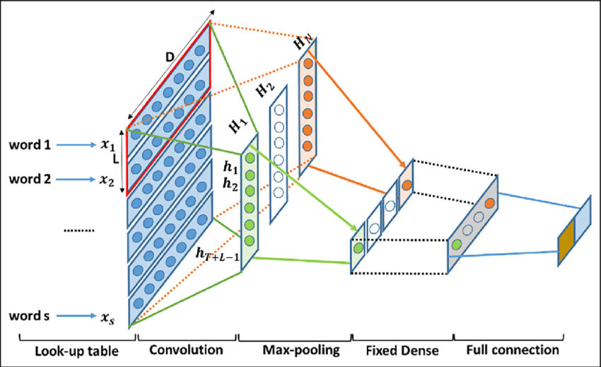

```python
class CNN(nn.Module):

    def __init__(self, size_voc):
        super().__init__()
        self.emb = nn.Embedding(size_voc, 128)
        #self.lin = nn.Linear(128, 128)#
        self.ls = nn.LSTM(128, 128, num_layers=3, batch_first=True, bidirectional=True)
        self.conv_0 = nn.Conv1d(in_channels = 1, out_channels = 64, kernel_size=(5, 256))
        self.conv_1 = nn.Conv1d(in_channels = 1, out_channels = 64, kernel_size=(8, 256))
        self.conv_2 = nn.Conv1d(in_channels = 1, out_channels = 64 , kernel_size=(10, 256))
        self.linear = nn.Linear(3*64, 77)#
        self.dropout = nn.Dropout(0.1)

    def forward(self, x):
        #x = self.lin(x)
        x,_ = self.ls(self.emb(x))
        embedded = x.unsqueeze(1)
        conved_0 = F.relu(self.conv_0(embedded.squeeze(3)))
        conved_1 = F.relu(self.conv_1(embedded.squeeze(3)))
        conved_2 = F.relu(self.conv_2(embedded.squeeze(3)))
        #print(conved_0.shape)
        #print(conved_0.squeeze(3).shape)
        pooled_0 = F.max_pool1d(conved_0.squeeze(3), conved_0.shape[2]).squeeze(2)
        pooled_1 = F.max_pool1d(conved_1.squeeze(3), conved_1.shape[2]).squeeze(2)
        pooled_2 = F.max_pool1d(conved_2.squeeze(3), conved_2.shape[2]).squeeze(2)
        out = self.dropout(torch.cat((pooled_0, pooled_1, pooled_2), dim = 1))
        out = self.linear(out)
        return torch.softmax(out, dim = 1)
```

Ограничим данные максимальной длинной предложения в 100 символов

```python
mask = [True if len(i)<100 else False for i in X_train1]
X_train2 = X_train1[mask].str.lower()
v1 = set(' '.join(X_train2.str.lower()))
vocab = Vocab(v1)
XX = DataIter(X_train2.values, y_train[mask].values, vocab)
```

```python
for i, j in XX:
    break
```

```python
model = CNN(len(vocab)).to(device)
```

```python
nn.CrossEntropyLoss()(torch.softmax(model(i.to(device)), dim=1), j.to(device))
```

```
tensor(4.3438, device='cuda:0', grad_fn=<NllLossBackward>)
```

```python
def f1_score_my(y_true, y_pred):
    y_t = y_true.cpu()
    y_p = y_pred.cpu()
    return f1_score(y_t, y_p, average='weighted')
```

Проверим что сетка учится на одном баче

```python
epochs = 20
lr = 0.0001
loss_func = nn.CrossEntropyLoss()
optimizer = torch.optim.Adam(model.parameters(), lr=lr)
for epoch in range(1, epochs+1):


    output = model(i.to(device))


    loss = loss_func(output , j.to(device))
    losses = float(loss)


    optimizer.zero_grad()
    loss.backward()
    optimizer.step()
    output = output.argmax(dim=1)
    f1 = f1_score_my(j, output)
    #f1.append(float(loss))

    print('F1: ',float(f1))
    print('Loss: ',float(losses))
    print('')
```

```
F1:  0.0
Loss:  4.3438262939453125

F1:  0.0
Loss:  4.343693733215332

F1:  0.06666666666666667
Loss:  4.343463897705078

F1:  0.02222222222222222
Loss:  4.343306541442871

F1:  0.03333333333333334
Loss:  4.343111038208008

F1:  0.01818181818181818
Loss:  4.342913627624512

F1:  0.019999999999999997
Loss:  4.342686653137207

F1:  0.08888888888888888
Loss:  4.342524528503418

F1:  0.02222222222222222
Loss:  4.3422698974609375

F1:  0.12
Loss:  4.342090606689453

F1:  0.01818181818181818
Loss:  4.341738700866699

F1:  0.019999999999999997
Loss:  4.341422080993652

F1:  0.0
Loss:  4.3411760330200195

F1:  0.0
Loss:  4.340442180633545

F1:  0.03333333333333334
Loss:  4.340092182159424

F1:  0.08
Loss:  4.339285850524902

F1:  0.025
Loss:  4.338679313659668

F1:  0.1
Loss:  4.337846755981445

F1:  0.04
Loss:  4.337375640869141

F1:  0.01818181818181818
Loss:  4.335618019104004
```

Вроде прогресс есть, теперь попробуем весь тренировочный набор

```python
from tqdm.notebook import trange, tqdm
```

```python
set_seed()
epochs = 5
lr = 0.001
loss_func = nn.CrossEntropyLoss()
model = CNN(len(vocab)).to(device)
mask = [True if len(i)<100 else False for i in X_train1]
X_train2 = X_train1[mask].str.lower()
v1 = set(' '.join(X_train2.str.lower()))
vocab = Vocab(v1)
XX = DataIter(X_train2.values, y_train[mask].values, vocab)


for epoch in trange(1, epochs+1):
    optimizer = torch.optim.Adam(model.parameters(), lr=lr)
    #lr/=1.2

    #Обучение
    model.train()
    f1 = []

    losses = []
    test_losses = []
    for batch in tqdm(XX, total=len(XX), leave = False):

        sample1, target = batch
        output = model(sample1.to(device))


        loss = loss_func(output , target.to(device))
        losses.append(float(loss))

        optimizer.zero_grad()
        loss.backward()
        optimizer.step()
        output = output.argmax(dim=1)
        loss = f1_score_my(target, output)
        f1.append(float(loss))
    print(f'Epoch {epoch} | F1 train: {round(sum(f1)/len(f1),3)} | loss train: {round(sum(losses)/len(losses),3)}' )
    print('')
```

```
Epoch 1 | F1 train: 0.005 | loss train: 4.342
```

```
Epoch 2 | F1 train: 0.021 | loss train: 4.323
```

```
Epoch 3 | F1 train: 0.059 | loss train: 4.286
```

```
Epoch 4 | F1 train: 0.106 | loss train: 4.24
```

```
Epoch 5 | F1 train: 0.198 | loss train: 4.148
```

Опыт со своей архитектурой завершился неудачей, в невошедших экспериментах я не смог добиться качества лучше 0.4 F1

Ничего не остаётся как пойти и взять берт и решить задачу

# Часть 4 Bert

Функции для обучения

```python
def step_opt(loss, opt):
    opt.zero_grad()
    loss.backward()
    opt.step()


def pas_batch(model, batch, criterion, train, opt):
    input, mask, labels = batch
    logits = model(input, mask).logits
    loss = criterion(logits, labels)
    y_true = labels.cpu().tolist()
    y_pred = logits.argmax(dim=-1).cpu().tolist()
    losses = loss.item()
    if train:
        step_opt(loss, opt)
    del input, mask, labels
    return losses, y_true, y_pred


def pas_epoch(model, loader, criterion, train = False, opt = None):
    model.train() if train else model.eval()
    losses, y_true, y_pred = 0, [], []

    for batch in loader:


        losses_batch, y_true_batch, y_pred_batch  = pas_batch(model, batch, criterion, train = train, opt = opt)
        losses += losses_batch
        y_true.extend(y_true_batch)
        y_pred.extend(y_pred_batch)

    f1 = f1_score(y_true, y_pred, average='weighted')
    losses = losses / len(loader)
    return losses, f1


def get_stat(model, loader, opt, criterion, train = True):
    if train:
        return pas_epoch(model, loader, criterion, train = True, opt = opt)
    else:
        with torch.no_grad():
            return pas_epoch(model, loader, criterion, train = False, opt = None)


def show_metrics(loss_train, loss_valid, f1_train, f1_valid):
    fig, (ax1, ax2) = plt.subplots(nrows=1, ncols=2, sharex=True,
                                        figsize=(12, 6))

    ax1.set_title('Loss')
    ax1.plot(loss_train, 'o-', label='train loss', linewidth=5, markersize=12)
    ax1.plot(loss_valid, 'o-', label='valid loss', linewidth=5, markersize=12)
    ax1.legend()

    ax2.set_title('F1')
    ax2.plot(f1_train, 'o-', label='train f1', linewidth=5, markersize=12)
    ax2.plot(f1_valid, 'o-', label='valid f1', linewidth=5, markersize=12)
    ax2.legend()
    fig.suptitle('Графики лоса и метрики F1')

    plt.show()


def train(model, loader, loader_val, opt, crit, device=device, n_epochs=20):
    set_seed()
    loss_train, loss_valid = [], []
    f1_train, f1_valid = [], []

    for n in range(1, n_epochs + 1):



        loss_train_epoch, f1_train_epoch = get_stat(model, loader, opt, criterion, train = True)


        loss_train.append(loss_train_epoch)
        f1_train.append(f1_train_epoch)

        loss_valid_epoch, f1_valid_epoch = get_stat(model, loader, opt, criterion, train = False)
        clear_output(True)
        print(f'{n} epoch')
        print(f'    f1_train: {f1_train_epoch:.4f} | loss_train: {loss_train_epoch:.4f}')
        print(f'    f1_valid: {f1_valid_epoch:.4f} | loss_valid: {loss_valid_epoch:.4f}')
        loss_valid.append(loss_valid_epoch)
        f1_valid.append(f1_valid_epoch)

        show_metrics(loss_train, loss_valid, f1_train, f1_valid)

        #torch.save(model.state_dict(), f'/content/my_model_epoch_{n}.pth')

    return loss_train, loss_valid, f1_train, f1_valid
```

```python
X_train1 = pd.read_csv('/content/trainn.csv').text
X_test1 = pd.read_csv('/content/testt.csv').text
```

Даталоадер с важностью равномерного сэмплинга классов.

```python
class DataIter:

    def __init__(self, text, label, tokenizer, device, batch_size=128, train = True, make_balance = False):
        set_seed()
        self.label = np.array(label)
        self.tokenizer = tokenizer
        self.text = np.array(text)
        self.n = len(self.label)
        self.index = np.arange(self.n)
        self.make_balance = make_balance
        if make_balance:
            self.train = False
            self.d = {}
            for i in range(77):
                self.d[i] = []
            for i, j in enumerate(label):
                self.d[j].append(i)
            self.max = self.n//154
        else:
            self.train = train
            self.max = self.n//batch_size
        if self.train:
            np.random.shuffle(self.index)

        self.device = device
        self.num = 0
        self.batch_size = batch_size


    def __len__(self):
        return self.max

    def __iter__(self):
        return self

    def __next__(self):
        if not self.make_balance and self.num <  self.max:
            ind = self.index[self.batch_size * self.num : self.batch_size * (self.num + 1)]
            tokens = self.tokenizer(self.text[ind].tolist(), return_tensors='pt', padding=True)
            label = torch.LongTensor(self.label[ind]).to(self.device)
            input = tokens.input_ids.to(self.device)
            mask = tokens.attention_mask.to(self.device)
            self.num += 1
            return input, mask, label
        elif self.make_balance and self.num <  self.max:
            ind = np.array([])
            for i in self.d.keys():
                ind = np.append(ind, np.random.choice(self.d[i], 2))
            ind = ind.astype('int64')
            tokens = self.tokenizer(self.text[ind].tolist(), return_tensors='pt', padding=True)
            label = torch.LongTensor(self.label[ind]).to(self.device)
            input = tokens.input_ids.to(self.device)
            mask = tokens.attention_mask.to(self.device)
            self.num += 1
            return input, mask, label
        else:
            self.num = 0
            if not self.make_balance and self.train:
                np.random.shuffle(self.index)
            raise StopIteration
```

Переключатель градиентов берта

```python
def switch_grad_bert(model, grad_on = True):
    for param in model.bert.parameters():
            param.requires_grad = grad_on
```

Итак основная идея состоит в том, что берём предобученный берт с классификатором.

Замораживаем веса берта и треним классификатор. Как только классификатор выйдет на плато,

то включаем веса берта и начинаем тренировать их с маленьким шагом.

Потом снова выключаем градиенты берта, треним классификатор, включаем градиенты и треним до убоя.

```python
set_seed()
weight2 = [w if w<2 else 2 for w in weight]
weight2 = torch.tensor(weight2).to(device) # на будующее
tokenizer = BertTokenizer.from_pretrained('bert-base-uncased', do_lower_case=True)
train_loader = DataIter(X_train1, y_train, tokenizer, device, batch_size=64, train = True, make_balance = False)
valid_loader = DataIter(X_test1, y_test, tokenizer, device, batch_size=128, train = False, make_balance = False)
criterion = nn.CrossEntropyLoss(weight = weight2) #
```

```python
model = BertForSequenceClassification.from_pretrained("bert-base-uncased", num_labels=77)
model.to(device)
print(1)
```

[output not shown]

```
1
```

```python
loss_train, loss_valid, f1_train, f1_valid = [], [], [], []
```

# Эксперимент 4.1

Обычный сэмплер и лосс с весами для корректировки дизбаланса классов

Чтобы компенсировать дизбаланс классов, накидываем весов на лосс.

```
15 epoch
    f1_train: 0.3311 | loss_train: 2.6227
    f1_valid: 0.4501 | loss_valid: 2.1495
```

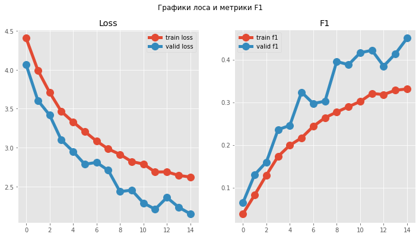

```python
switch_grad_bert(model, grad_on = False)
set_seed()
optimizer = torch.optim.Adam(model.classifier.parameters(), lr=0.004)
loss_train_e, loss_valid_e, f1_train_e, f1_valid_e = train(model,
            train_loader, valid_loader, optimizer, criterion, device=device, n_epochs=15)
loss_train.extend(loss_train_e)
loss_valid.extend(loss_valid_e)
f1_train.extend(f1_train_e)
f1_valid.extend(f1_valid_e)
```

```
15 epoch
    f1_train: 0.8371 | loss_train: 0.5397
    f1_valid: 0.8903 | loss_valid: 0.3592
```

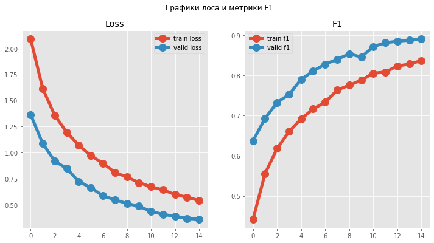

```python
switch_grad_bert(model, grad_on = True)
set_seed()
optimizer = torch.optim.Adam([{'params':model.bert.parameters(), 'lr':3e-7},
                              {'params':model.classifier.parameters(), 'lr':0.002}])
loss_train_e, loss_valid_e, f1_train_e, f1_valid_e = train(model,
            train_loader, valid_loader, optimizer, criterion, device=device, n_epochs=15)
loss_train.extend(loss_train_e)
loss_valid.extend(loss_valid_e)
f1_train.extend(f1_train_e)
f1_valid.extend(f1_valid_e)
```

```
5 epoch
    f1_train: 0.8543 | loss_train: 0.4781
    f1_valid: 0.9111 | loss_valid: 0.3024
```

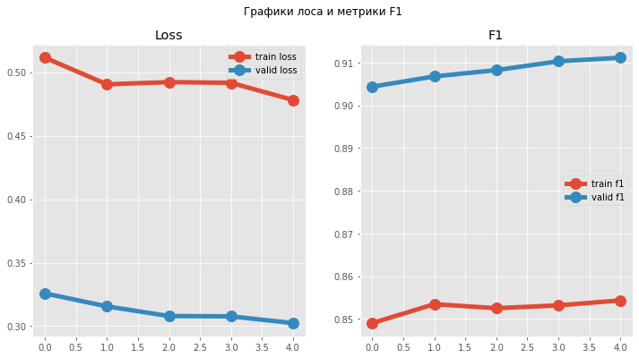

```python
switch_grad_bert(model, grad_on = False)
set_seed()
optimizer = torch.optim.Adam(model.classifier.parameters(), lr=0.001)
loss_train_e, loss_valid_e, f1_train_e, f1_valid_e = train(model,
            train_loader, valid_loader, optimizer, criterion, device=device, n_epochs=5)
loss_train.extend(loss_train_e)
loss_valid.extend(loss_valid_e)
f1_train.extend(f1_train_e)
f1_valid.extend(f1_valid_e)
```

```
11 epoch
    f1_train: 0.9243 | loss_train: 0.2388
    f1_valid: 0.9627 | loss_valid: 0.1262
```

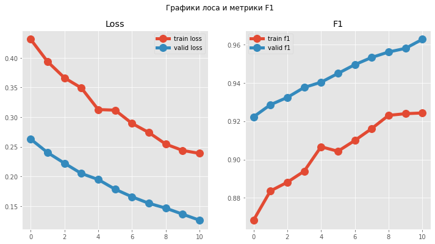

```python
switch_grad_bert(model, grad_on = True)
set_seed()
optimizer = torch.optim.Adam([{'params':model.bert.parameters(), 'lr':1e-6},
                              {'params':model.classifier.parameters(), 'lr':0.0001}])
loss_train_e, loss_valid_e, f1_train_e, f1_valid_e = train(model,
            train_loader, valid_loader, optimizer, criterion, device=device, n_epochs=11)
loss_train.extend(loss_train_e)
loss_valid.extend(loss_valid_e)
f1_train.extend(f1_train_e)
f1_valid.extend(f1_valid_e)
```

```
Лучшее значение F1 на трейне: 0.9243 | на валидации: 0.9627
```

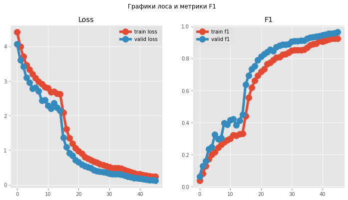

```python
print(f'Лучшее значение F1 на трейне: {max(f1_train):.4f} | на валидации: {max(f1_valid):.4f}')
show_metrics(loss_train, loss_valid, f1_train, f1_valid)
```

Кроме в модели не полностью реализован потенциал и даже не наблюдается признаков переобучения, но у меня просто поджимали сроки, поэтому мне пришлось остановиться на этом результате.

```python
torch.save(model.state_dict(), '/content/drive/MyDrive/data_for_tinkoff/my_model_loss_with_weight.pt')
```

```python
model.load_state_dict(torch.load('/content/drive/MyDrive/data_for_tinkoff/my_model_loss_with_weight.pt'))
```

# Эксперимент 4.2

Обычный сэмплер и лосс без весов

```python
set_seed()
model = BertForSequenceClassification.from_pretrained("bert-base-uncased", num_labels=77)
model.to(device)

criterion = nn.CrossEntropyLoss() #
loss_train, loss_valid, f1_train, f1_valid = [], [], [], []
```

[output not shown]

```
15 epoch
    f1_train: 0.3970 | loss_train: 2.4053
    f1_valid: 0.5689 | loss_valid: 1.9098
```

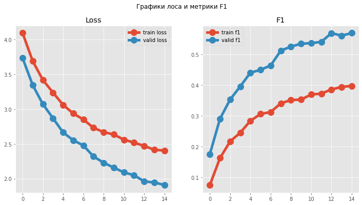

```python
switch_grad_bert(model, grad_on = False)
set_seed()
optimizer = torch.optim.Adam(model.classifier.parameters(), lr=0.004)
loss_train_e, loss_valid_e, f1_train_e, f1_valid_e = train(model,
            train_loader, valid_loader, optimizer, criterion, device=device, n_epochs=15)
loss_train.extend(loss_train_e)
loss_valid.extend(loss_valid_e)
f1_train.extend(f1_train_e)
f1_valid.extend(f1_valid_e)
```

```
15 epoch
    f1_train: 0.8175 | loss_train: 0.6470
    f1_valid: 0.8681 | loss_valid: 0.4673
```

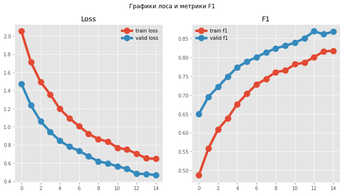

```python
switch_grad_bert(model, grad_on = True)
set_seed()
optimizer = torch.optim.Adam([{'params':model.bert.parameters(), 'lr':3e-7},
                              {'params':model.classifier.parameters(), 'lr':0.002}])
loss_train_e, loss_valid_e, f1_train_e, f1_valid_e = train(model,
            train_loader, valid_loader, optimizer, criterion, device=device, n_epochs=15)
loss_train.extend(loss_train_e)
loss_valid.extend(loss_valid_e)
f1_train.extend(f1_train_e)
f1_valid.extend(f1_valid_e)
```

```
5 epoch
    f1_train: 0.8392 | loss_train: 0.5702
    f1_valid: 0.8828 | loss_valid: 0.4072
```

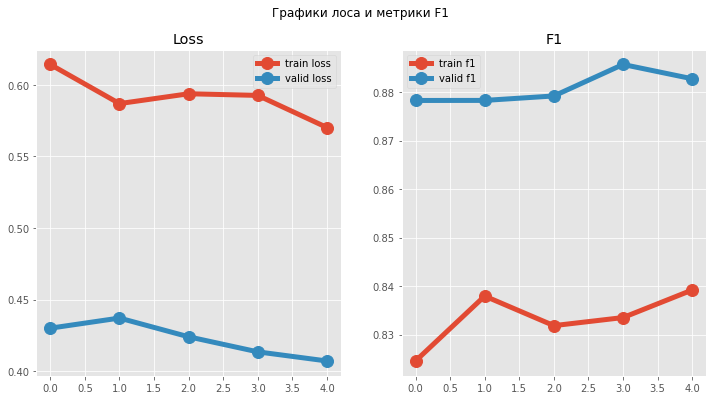

```python
switch_grad_bert(model, grad_on = False)
set_seed()
optimizer = torch.optim.Adam(model.classifier.parameters(), lr=0.001)
loss_train_e, loss_valid_e, f1_train_e, f1_valid_e = train(model,
            train_loader, valid_loader, optimizer, criterion, device=device, n_epochs=5)
loss_train.extend(loss_train_e)
loss_valid.extend(loss_valid_e)
f1_train.extend(f1_train_e)
f1_valid.extend(f1_valid_e)
```

```
11 epoch
    f1_train: 0.9122 | loss_train: 0.3021
    f1_valid: 0.9328 | loss_valid: 0.2181
```

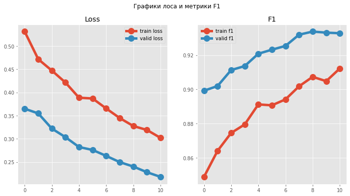

```python
switch_grad_bert(model, grad_on = True)
set_seed()
optimizer = torch.optim.Adam([{'params':model.bert.parameters(), 'lr':1e-6},
                              {'params':model.classifier.parameters(), 'lr':0.0001}])
loss_train_e, loss_valid_e, f1_train_e, f1_valid_e = train(model,
            train_loader, valid_loader, optimizer, criterion, device=device, n_epochs=11)
loss_train.extend(loss_train_e)
loss_valid.extend(loss_valid_e)
f1_train.extend(f1_train_e)
f1_valid.extend(f1_valid_e)
```

```
Лучшее значение F1 на трейне: 0.9122 | на валидации: 0.9338
```

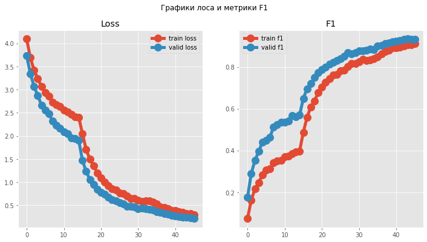

```python
print(f'Лучшее значение F1 на трейне: {max(f1_train):.4f} | на валидации: {max(f1_valid):.4f}')
show_metrics(loss_train, loss_valid, f1_train, f1_valid)
```

Результаты неплохие, но до эксперимента 4.1 не дотягивают.

```python
torch.save(model.state_dict(), f'/content/drive/MyDrive/data_for_tinkoff/my_model_loss_without_weight.pt')
```

# Эксперимент 4.3

Сэмплер с балансировкой

```python
set_seed()
model = BertForSequenceClassification.from_pretrained("bert-base-uncased", num_labels=77)
model.to(device)
train_loader = DataIter(X_train1, y_train, tokenizer, device, batch_size=64, train = True, make_balance = True)
valid_loader = DataIter(X_test1, y_test, tokenizer, device, batch_size=128, train = False, make_balance = False)
loss_train, loss_valid, f1_train, f1_valid = [], [], [], []
criterion = nn.CrossEntropyLoss()
```

[output not shown]

[output not shown]

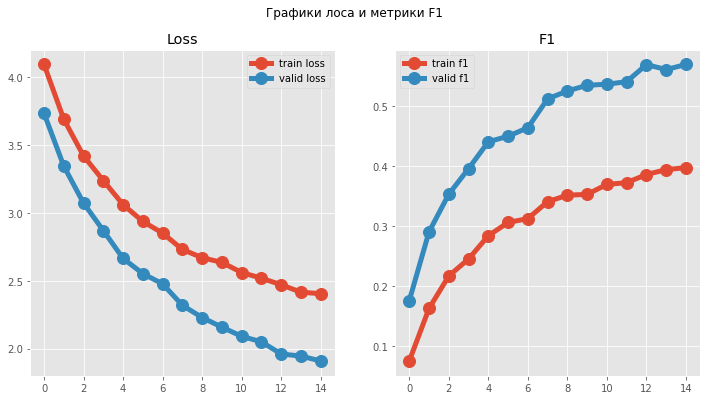

```python
switch_grad_bert(model, grad_on = False)
set_seed()
optimizer = torch.optim.Adam(model.classifier.parameters(), lr=0.004)
loss_train_e, loss_valid_e, f1_train_e, f1_valid_e = train(model,
            train_loader, valid_loader, optimizer, criterion, device=device, n_epochs=15)
loss_train.extend(loss_train_e)
loss_valid.extend(loss_valid_e)
f1_train.extend(f1_train_e)
f1_valid.extend(f1_valid_e)
```

```
15 epoch
    f1_train: 0.8175 | loss_train: 0.6470
    f1_valid: 0.8681 | loss_valid: 0.4673
```

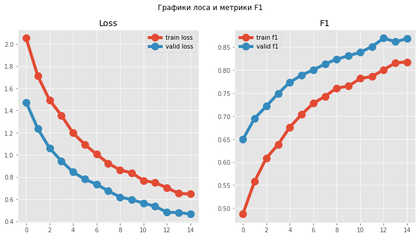

```python
switch_grad_bert(model, grad_on = True)
set_seed()
optimizer = torch.optim.Adam([{'params':model.bert.parameters(), 'lr':3e-7},
                              {'params':model.classifier.parameters(), 'lr':0.002}])
loss_train_e, loss_valid_e, f1_train_e, f1_valid_e = train(model,
            train_loader, valid_loader, optimizer, criterion, device=device, n_epochs=15)
loss_train.extend(loss_train_e)
loss_valid.extend(loss_valid_e)
f1_train.extend(f1_train_e)
f1_valid.extend(f1_valid_e)
```

```
5 epoch
    f1_train: 0.8392 | loss_train: 0.5702
    f1_valid: 0.8828 | loss_valid: 0.4072
```

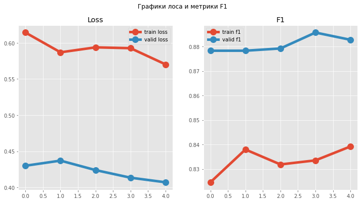

```python
switch_grad_bert(model, grad_on = False)
set_seed()
optimizer = torch.optim.Adam(model.classifier.parameters(), lr=0.001)
loss_train_e, loss_valid_e, f1_train_e, f1_valid_e = train(model,
            train_loader, valid_loader, optimizer, criterion, device=device, n_epochs=5)
loss_train.extend(loss_train_e)
loss_valid.extend(loss_valid_e)
f1_train.extend(f1_train_e)
f1_valid.extend(f1_valid_e)
```

```
11 epoch
    f1_train: 0.9122 | loss_train: 0.3021
    f1_valid: 0.9328 | loss_valid: 0.2181
```

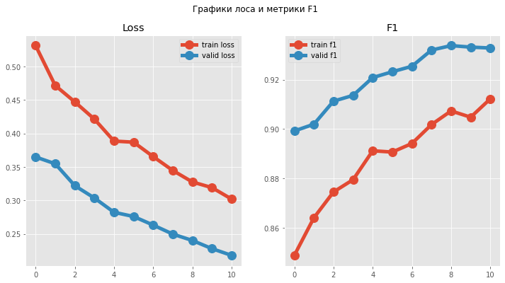

```python
switch_grad_bert(model, grad_on = True)
set_seed()
optimizer = torch.optim.Adam([{'params':model.bert.parameters(), 'lr':1e-6},
                              {'params':model.classifier.parameters(), 'lr':0.0001}])
loss_train_e, loss_valid_e, f1_train_e, f1_valid_e = train(model,
            train_loader, valid_loader, optimizer, criterion, device=device, n_epochs=11)
loss_train.extend(loss_train_e)
loss_valid.extend(loss_valid_e)
f1_train.extend(f1_train_e)
f1_valid.extend(f1_valid_e)
```

```
Лучшее значение F1 на трейне: 0.9122 | на валидации: 0.9338
```

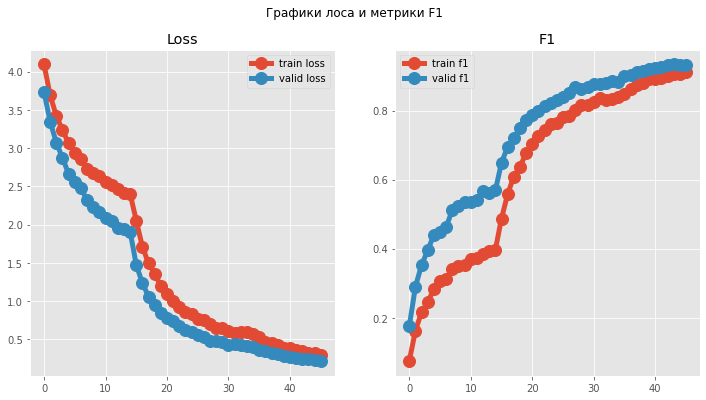

```python
print(f'Лучшее значение F1 на трейне: {max(f1_train):.4f} | на валидации: {max(f1_valid):.4f}')
show_metrics(loss_train, loss_valid, f1_train, f1_valid)
```

```python
torch.save(model.state_dict(), f'/content/drive/MyDrive/data_for_tinkoff/my_model_loss_with_sampl.pt')
```

# Эксперимент 4.4

Лосс из статьи

Пытался сделать свой лосс, но работает не очень хорошо.

```python
class SADL(torch.nn.Module):

    def __init__(self, alpha = 1.0, gamma = 1.0):
        super(SADL, self).__init__()
        self.alpha = alpha
        self.gamma = gamma


    def forward(self, logits, targets):
        p = torch.softmax(logits, dim=1)
        y = torch.zeros_like(logits)
        y[range(logits.shape[0]),targets] = 1
        a = ((1 - p) ** self.alpha) * p
        loss =  1 - (2 * a * y + self.gamma) / (a + y + self.gamma)
        return loss.mean()
```

```python
criterion = SADL()
set_seed()
train_loader = DataIter(X_train1, y_train, tokenizer, device, batch_size=64, train = True, make_balance = False)
valid_loader = DataIter(X_test1, y_test, tokenizer, device, batch_size=128, train = False, make_balance = False)
loss_train, loss_valid, f1_train, f1_valid = [], [], [], []

model = BertForSequenceClassification.from_pretrained("bert-base-uncased", num_labels=77)
model.to(device)
print(1)
```

[output not shown]

```
1
```

```
8 epoch
    f1_train: 0.0004 | loss_train: 0.0065
    f1_valid: 0.0004 | loss_valid: 0.0065
```

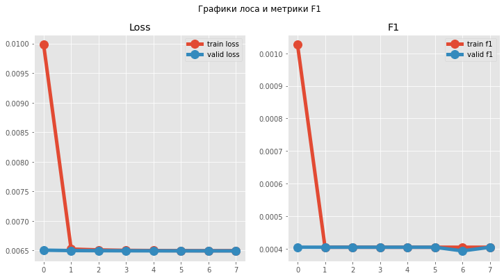

```python
switch_grad_bert(model, grad_on = False)
set_seed()
optimizer = torch.optim.Adam(model.classifier.parameters(), lr=0.0003)
loss_train_e, loss_valid_e, f1_train_e, f1_valid_e = train(model,
            train_loader, valid_loader, optimizer, criterion, device=device, n_epochs=8)
loss_train.extend(loss_train_e)
loss_valid.extend(loss_valid_e)
f1_train.extend(f1_train_e)
f1_valid.extend(f1_valid_e)
```

```
Лучшее значение F1 на трейне: 0.0010 | на валидации: 0.0004
```

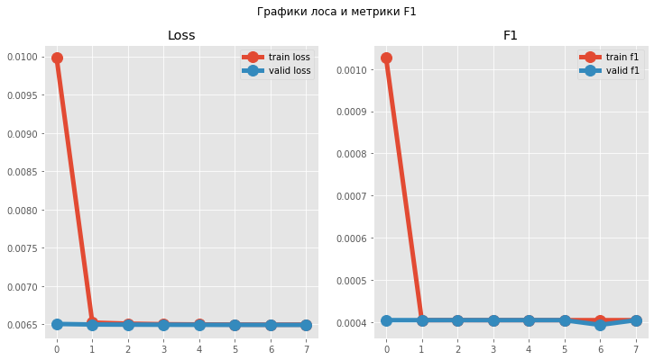

```python
print(f'Лучшее значение F1 на трейне: {max(f1_train):.4f} | на валидации: {max(f1_valid):.4f}')
show_metrics(loss_train, loss_valid, f1_train, f1_valid)
```

Я нашёл реализацию данного лосса на гитхабе ссылка: https://github.com/fursovia/self-adj-dice/tree/4d70d87a05afa154d1002acebd95848f833db342

Кажется это Ваш сотрудник Иван Фурсов (Чайников Константин с тинькофф поколения передаёт тебе привет), кажется у него правильно реализован лосс

```python
!pip install sadice
from sadice import SelfAdjDiceLoss #
```

```python
criterion = SelfAdjDiceLoss()
set_seed()
train_loader = DataIter(X_train1, y_train, tokenizer, device, batch_size=64, train = True, make_balance = False)
valid_loader = DataIter(X_test1, y_test, tokenizer, device, batch_size=128, train = False, make_balance = False)
loss_train, loss_valid, f1_train, f1_valid = [], [], [], []

model = BertForSequenceClassification.from_pretrained("bert-base-uncased", num_labels=77)
model.to(device)
print(1)
```

[output not shown]

```
1
```

```
8 epoch
    f1_train: 0.0370 | loss_train: 0.4802
    f1_valid: 0.0446 | loss_valid: 0.4780
```

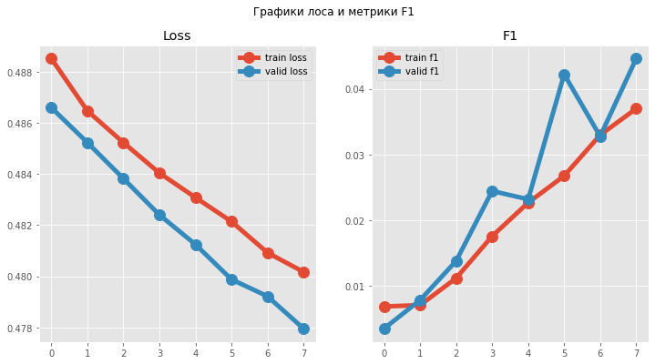

```python
switch_grad_bert(model, grad_on = False)

set_seed()
optimizer = torch.optim.Adam(model.classifier.parameters(), lr=0.0003)

loss_train_e, loss_valid_e, f1_train_e, f1_valid_e = train(model,
            train_loader, valid_loader, optimizer, criterion, device=device, n_epochs=8)
loss_train.extend(loss_train_e)
loss_valid.extend(loss_valid_e)
f1_train.extend(f1_train_e)
f1_valid.extend(f1_valid_e)
```

Явного прогресса не наблюдается

```
Лучшее значение F1 на трейне: 0.0370 | на валидации: 0.0446
```

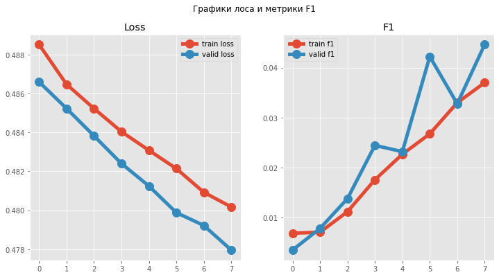

```python
print(f'Лучшее значение F1 на трейне: {max(f1_train):.4f} | на валидации: {max(f1_valid):.4f}')
show_metrics(loss_train, loss_valid, f1_train, f1_valid)
```

# Выводы

Итого берт с лосом кросс энтропии с весами показал наилучшие результаты. Моя реализация Лосса из статьи не работает здесь, лосс из статьи Ивана Фурсова тоже не показал хорошие результаты.

**Возможные улучшения:**

- Можно попробовать дальше поэскпериментировать с комбинированием подходов, например взять в самом начале балансированное сэмплирование и обычным лоссом, потом вернуться к обычному сэплмированию, но взять лосс с весами.
- Взять берт побольше или дольше обучить этот берт
- Возможно стоит попробовать обучить сеть на tfidf/count кодировке предложений.
- Реализовать Labelsmoothing

```python
!jupyter nbconvert --to html Testovoe_tinkoff_chainikov_konstantin.ipynb
```

```
[NbConvertApp] Converting notebook Testovoe_tinkoff_chainikov_konstantin.ipynb to html
[NbConvertApp] Writing 1695768 bytes to Testovoe_tinkoff_chainikov_konstantin.html
```